# 1. 데이터형이란(Data Type)?

- 변수나 상수의 종류를 의미함
- 그릇의 용도에 따라 국그릇, 밥그릇이 있듯이 변수의 종류도 다양함

### 1) 4가지 기본 데이터형

- 정수형(int), 실수형(float), 문자열형(str), 불형(bool) 변수가 있음.
  - 정수(Integer) : 소수점이 없는 양의 정수, 음의 정수, 0으로 이루어진 숫자의 집합. 예시 : 1, -2, 0 등
  - 실수(Float) : 소수점을 포함한 숫자의 집합으로, 정수와 소수로 구성된다. 예시 : 3.14, -2.5 등.
  - 문자열(String) : 문자들의 연속된 집합으로, 작은따옴표(')나 큰따옴표(")로 묶어서 표현한다. 예시 : 'Hello World', "Python" 등.
  - 불(Bool) : 참(True)과 거짓(False) 두 가지 값 중 하나만을 가지는 데이터형. 조건식에서 자주 사용된다. 예시 : True, False.

[figure not shown]

- 각각의 변수 4개를 준비한다. (var1, var2, var3, var4 )

```python
var1 = 100          # 정수형 변수
var2 = 3.14         # 실수형 변수
var3 = "파이썬"     # 문자열형 변수
var4 = True        # 불형 변수

print(var1)
print(var2)
print(var3)
print(var4)
```

```
100
3.14
파이썬
True
```

### 2) type() 함수

- 파이썬 내장 함수 중 하나로, 주어진 객체의 데이터 타입을 반환하는 함수
- 이 함수를 사용하면 변수(그릇)의 종류를 확인할 수 있다.

```python
type(var1) # 정수형 변수
```

```
int
```

```python
type(var2) # 실수형 변수
```

```
float
```

```python
type(var3) # 문자열형 변수
```

```
str
```

```python
type(var4) # 불형 변수
```

```
bool
```

### + type() 함수를 사용하여 데이터 형식을 확인하기

- "Hello, World!"
- -12.0
- False
- 1

**접기/펼치기**

data_type_1 = "Hello, World!"  
data_type_2 = -12.0  
data_type_3 = False  
data_type_4 = 1  
print("data_type_1: ", type(data_type_1)) # 문자열형  
print("data_type_2: ", type(data_type_2)) # 실수형  
print("data_type_3: ", type(data_type_3)) # 불형  
print("data_type_4: ", type(data_type_4)) # 정수형

### 3) 들어있는 데이터에 따라 변하는 변수의 데이터형

- 현재 정수형인 var1에 문자열 "Hello" 넣고 type()으로 확인해보기
- 데이터 타입도 고정되지 않고 함께 바뀜을 알 수 있음

※ 변수에 새로운 값을 넣으면 기존 값을 덮어쓰게 된다. 파이썬에서 변수는 메모리 공간을 참조하는 이름에 불과하기에 변수에 새로운 값을 넣으면, 이전에 참조하고 있던 메모리 공간을 덮어쓰게되는 것이다. 이는 메모리를 효율적으로 사용하기 위한 방법 중 하나이다.

[figure not shown]

#### ▶ 변수 var1에 정수 100을 넣었을 때

```python
var1 = 100
```

```python
type(var1)
```

```
int
```

#### ▶ 변수 var1에 정수 100이 담겨 있는 상황에서 다시 "Hello"를 넣었을 때

```python
var1 = "Hello"
```

```python
type(var1)
```

```
str
```

#### ▶ 담기는 내용에 따른 데이터형의 변화

```python
var1 = 100
print(type(var1))    # 정수형 변수

var1 = 3.14
print(type(var1))   # 실수형 변수

var1 = "파이썬"
print(type(var1))   # 문자열형 변수

var1 = True
print(type(var1))  # 불형 변수
```

```
<class 'int'>
<class 'float'>
<class 'str'>
<class 'bool'>
```

#### ▶ 데이터의 타입 변환, 형변환

- int(), str(), float() 등

```python
num_str = "10"
num_int = int(num_str)  # 문자열 "10"을 정수형으로 변환
num_float = float(num_int)  # 정수형 10을 실수형으로 변환
```

```python
num_float
```

```
10.0
```

```python
type(num_float)
```

```
float
```

# 2. 데이터형의 종류

- 기본적인 데이터 형식 네 가지(정수형, 실수형, 문자열형, 불형)에 대해 살펴보자

### 1) 숫자데이터 형식

- 숫자데이터 형식은 소수점의 여부에 따라 크게 정수형(integer)과 실수형(Float)로 나눌 수 있다.

#### ▶ 정수형( integer )

- 소수점이 없는 수
- 10, -300, 0 등
- int의 크기에 제한이 없음

```python
var = 123
type(123)
```

```
int
```

```python
var1 = -300
type(var1)
```

```
int
```

- 큰 숫자도 저장할 수 있기 때문에 저장 가능한 크기에 제한은 없다.
- 하지만 너무 큰 숫자를 다루게 되면, 처리 속도가 느려질 수 있다.

```python
var2 = 100**100 #100의 100승

print(var2)
```

```
100000000000000000000000000000000000000000000000000000000000…
```

```python
type(var2)
```

```
int
```

#### 1000의 1000승

```python
var3 = 1000**1000
```

```python
print(var3)
```

```
100000000000000000000000000000000000000000000000000000000000…
```

#### ▶ 실수형( float )

- 소수점이 있는 수
- 3.14, -8.8, 0.1 등

```python
var = 3.14
type(var)
```

```
float
```

```python
var1 = -8.8
type(var1)
```

```
float
```

```python
var2 = 0.1
type(var2)
```

```
float
```

### 1-1) 정수와 실수의 연산

- 정수와 정수의 연산은 정수
- 실수와 실수의 연산은 실수
- 정수와 실수의 연산은 실수
- 정수와 정수여도 나눗셈을 하면 실수가 나옴

[figure not shown]

#### 정수와 정수의 연산

```python
var1 = 100 # 정수
var2 = 200 # 정수
res = var1 + var2 # 정수와 정수의 연산
print(res) # 결과도 정수
```

```
300
```

```python
type (res)
```

```
int
```

#### 실수와 실수의 연산

```python
var1 = 100.0 # 실수
var2 = 200.0 # 실수
res = var1 + var2 #실수와 실수의 연산
print(res) # 결과도 실수
```

```
300.0
```

```python
type (res)
```

```
float
```

#### 정수와 실수의 연산

```python
var1 = 100 # 정수
var2 = 200.0 # 실수
res = var1 + var2 # 정수와 실수의 연산
print(res) # 결과는 실수
```

```
300.0
```

```python
type(res)
```

```
float
```

[figure not shown]

#### ※ 정수와 정수의 나눗셈

```python
var1 = 100 # 정수
var2 = 200 # 정수
res = var1 / var2 # 정수와 정수의 나눗셈
print(res) # 결과는 실수
```

```
0.5
```

```python
type(res)
```

```
float
```

### 2) 문자 데이터 형식

#### ▶ 문자열(String)형

- 약자로 str로 표현함
- 글자들의 집합
- “파이썬“, “python”, ’123’ 등
- 문자열은 양쪽을 큰따옴표(“”)나 작은따옴표(‘ ’)로 감싸야 함
- 중간에 띄어쓰기가 있어도 상관 없음

```python
var1 = "난생처음 파이썬"
print(var1)
```

```
난생처음 파이썬
```

```python
type(var1)
```

```
str
```

### 3) 불 데이터 형식

#### ▶ 불(Bool)형

- 참(True)이나 거짓(False)만 저장할 수 있는 데이터 형식
- 논리형이라고도 함

```python
var1 = (100 > 10) # 100이 10보다 큰가?
print(var1)
```

```
True
```

```python
var2 = (100 <= 20) # 100이 20보다 작거나 같은가?
print(var2)
```

```
False
```

[figure not shown]

# 3. 문자열 알아보기

### 1) 문자열 만들기

- 큰따옴표 또는 작은따옴표로 묶어서 표현
- 문자열은 0개의 글자부터 여러 개의 글자까지 모두 문자열로 취급함

#### 여러 글자의 문자열

```python
var1 = "난생처음 파이썬" # 큰따옴표 사용
var2 = '난생처음 파이썬' # 작은따옴표 사용
```

```python
print(var1)
print(var2)
```

```
난생처음 파이썬
난생처음 파이썬
```

```python
print("var1 type : ", type(var1))
print("var2 type : ", type(var2))
```

```
var1 type :  <class 'str'>
var2 type :  <class 'str'>
```

#### 한 글자의 문자열

```python
var1 = "난" # 큰따옴표 사용
var2 = '난' # 작은따옴표 사용
```

```python
print(var1)
print(var2)
```

```
난
난
```

```python
print("var1 type : ", type(var1))
print("var2 type : ", type(var2))
```

```
var1 type :  <class 'str'>
var2 type :  <class 'str'>
```

#### 0개 글자의 문자열

```python
var1 = ""
var2 = ''
```

```python
print(var1)
print(var2)
```

```python
print("var1 type : ", type(var1))
print("var2 type : ", type(var2))
```

```
var1 type :  <class 'str'>
var2 type :  <class 'str'>
```

### 1-1) 여러 줄의 문자열을 표현하기

- 여러줄의 문자열을 한 번에 표현하고 싶다면, 큰따옴표나 작은따옴표를 3개 연속 사용해서 묶어준다

```python
var1 = """난생
처음
파이
썬을
열공
중입
니다."""
```

```python
print(var1)
```

```
난생
처음
파이
썬을
열공
중입
니다.
```

#### ※ 에러 발생

- 따옴표로 끝을 닫아주지 않아 생기는 에러
- 여러줄의 문자열 표현하고자 하였으나, 하나의 따옴표만 사용

```python
var1 = "난생처음
파이썬을
열공 중입니다."
```

```
  Input In [58]
    var1 = "난생처음
                ^
SyntaxError: EOL while scanning string literal
```

### 2) 이스케이프 문자 활용

- 1-1 에서는 세 개의 따옴표를 연속으로 사용하여 [enter]를 포함해 한 변수에 여러 행을 저장할 수 있었다.
- " \n " 를 사용해서 위와 같은 효과를 낼 수 있다.
- " \n " 는 줄바꿈 하라는 의미로 [enter]와 동일한 효과를 낸다.
- 이런 것을 이스케이프 문자, 또는 서식 문자라고 부른다.

```python
var2 = "난생처음\n파이썬을 \n열공 중입니다."
```

```python
print(var2)
```

```
난생처음
파이썬을
열공 중입니다.
```

### 이스케이프(escape) 문자란?

- 서식 문자라고도 부름
- 이스케이프 문자는 앞에 \ (백슬래시)를 붙여 주어야 함
- 파이썬에서 주로 사용되는 이스케이프 문자를 정리하면 다음과 같다

[figure not shown]

### 많이 사용하는 이스케이프 문자

▶ \n : 새로운 줄로 이동

```python
print("줄바꿈\n연습")
```

```
줄바꿈
연습
```

▶ \t : 다음 탭으로 이동

```python
print("다음탭으로\t이동")
```

```
다음탭으로	이동
```

▶ \', \" : 큰 따옴표, 작은 따옴표를 출력

```python
print("글자를 \"강조\"하는 효과 1")
print('글자를 \'강조\'하는 효과 2')
```

```
글자를 "강조"하는 효과 1
글자를 '강조'하는 효과 2
```

▶ \\ : \를 출력

- \만 출력할 경우 오류 발생

```python
print("\")
```

```
  Input In [76]
    print("\")
              ^
SyntaxError: EOL while scanning string literal
```

- \를 하만 사용하여 출력할 수 있으나, \ 바로 뒤에 따옴표 같이 이스케이프 문자로 취급될 수 있는 문자가 오면 안됨
- 따라서 \ 를 두개 사용하여 출력하거나, 공백을 추가해서 출력해줘야함

```python
print("\\")
print("\ ")
```

```
\
\
```

### 3) 문자열 연결하기

- 더하기(+) 연산자 사용
- 간단하게 더하기 연산자를 사용하면 띄어쓰기 없이 문자열이 연결됨
- 여러 행에 이어서 연결해 사용할 수도 있음

[figure not shown]

**※ 변수란? (접기/펼치기)**

- 변수(Variable)란 값을 저장할 수 있는 저장공간
- 변수의 이름은 자기 마음대로 지어도 됨
- 코드를 공유할 때를 고려하여 변수의 이름만 보고도 의미를 파악할 수 있어야 함
- 좋은 변수 이름은 짧으면서도 그 의미를 파악할 수 있는 것

[figure not shown]

#### ▶ 하나의 변수 안에 더하기(+)를 사용하여 연결

**접기/펼치기**

[figure not shown]

```python
var1 = "난생" + "처음" + "파이썬"
print(var1)
```

```
난생처음파이썬
```

#### ▶ 여러개의 변수를 print()함수 안에서 더하기(+)를 사용하여 연결

**접기/펼치기**

[figure not shown]

```python
var1 = "난생"
var2 = "처음"
var3 = "파이썬"

print(var1+var2+var3)
```

```
난생처음파이썬
```

#### ▶ 여러개의 변수를 연결하여 새로운 변수에 저장하여 출력

**접기/펼치기**

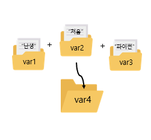

```python
var1 = "난생"
var2 = "처음"
var3 = "파이썬"
var4 = var1+var2+var3
print(var4)
```

```
난생처음파이썬
```

#### ▶ += 복합 대입 연산자의 활용

```python
var1 = "난생"
print(var1)

var1 += "처음"  #  var1 = var1 + "처음"
print(var1)

var1 += "파이썬"
print(var1)
```

```
난생
난생처음
난생처음파이썬
```

#### ▶문자열을 더하기(+)를 사용하여 이어서 출력하기

```python
var1, var2, var3, var4 =  "기초와", "활용", "지능", "인공"
```

```python
var5= var4 +var3 + var1 +var2
print(var5)
```

```
인공지능기초와활용
```

### 3-1) 문자열 연결 시 주의사항

- 문자열과 숫자는 데이터형이 다르기 때문에 더할 수 없음
- 문자열끼리의 뺄셈, 곱셈, 나눗셈도 모두 오류 발생함
- 문자열에 숫자를 곱하는 것은 가능함
- "난생"에서 "처음"을 빼거나 나눈다는 것 자체가 논리적으로 성립되지 않기 때문

**접기/펼치기**

[figure not shown]

#### ▶ 문자열 - 문자열

- 오류 발생

```python
var1 = "난생" - "처음"
```

```
---------------------------------------------------------------------------
TypeError                                 Traceback (most recent call last)
Input In [133], in <cell line: 1>()
----> 1 var1 = "난생" - "처음"

TypeError: unsupported operand type(s) for -: 'str' and 'str'
```

#### ▶ 문자열 * 문자열

- 오류 발생

```python
var2 = "난생" * "처음"
```

```
---------------------------------------------------------------------------
TypeError                                 Traceback (most recent call last)
Input In [134], in <cell line: 1>()
----> 1 var2 = "난생" * "처음"

TypeError: can't multiply sequence by non-int of type 'str'
```

#### ▶ 문자열 / 문자열

- 오류 발생

```python
var3 = "난생" / "처음"
```

```
---------------------------------------------------------------------------
TypeError                                 Traceback (most recent call last)
Input In [135], in <cell line: 1>()
----> 1 var3 = "난생" / "처음"

TypeError: unsupported operand type(s) for /: 'str' and 'str'
```

#### ▶ 문자열 *숫자

- 문자열과 숫자 간에는 연산이 불가능하지만, * (곱하기)는 문자열을 n번 반복하라는 의미

```python
var4 = "난생" * 3  # 곱한 만큼의 문자열 반복
print(var4)
```

```
난생난생난생
```

```python
var5 = "오늘 "
var6 = "정말"
var7 = " 더워요"

print(var5 +var6*3 + var7)
```

```
오늘 정말정말정말 더워요
```

### 4) 문자열과 관련된 유용한 함수

- 문자열을 직접 다루는 것이 쉽지 않을 때가 있다.
- 이럴 때는 파이썬에서 제공하는 문자열 관련 함수를 사용하면 편리하다

### ① len( )

- len은 "length" 길이 라는 영어의 약자
- 문자열의 길이를 파악할 때 사용함
- 한글, 기호, 영문, 공백, 숫자까지 모두 글자로 취급함
- len()을 통해 구한 문자열 등의 길이는 모두 숫자로 반환됨

#### ▶ len() 안에 문자열을 입력하여 길이 구하기

```python
len("난생처음! Python")
```

```
12
```

```python
len("23년 3월")
```

```
6
```

#### ▶ 변수안에 담긴 문자열의 길이 구하기

```python
var1 = "난생처음! Python"
```

```python
len(var1)
```

```
12
```

#### ▶ print()와 len()을 같이 사용해보기

ⓛ print()안에 len()을 사용하여 변수의 문자열 길이를 바로 출력

```python
var1 = "난생처음"
```

```python
print(len(var1), "자")
```

```
4 자
```

② len()으로 구한 문자열 길이를 새로운 변수에 할당하여 사용

```python
var1 = "python"
```

```python
var2 = len(var1) # python의 길이는 6
```

```python
print(var2, "자")
```

```
6 자
```

#### ▶ input( ), print( ), len( )을 같이 사용해보기

```python
var1 = input("문자열을 입력해주세요 ==> ")
var2 = len(var1)
print(var2, "자")
```

```
문자열을 입력해주세요 ==> 데이터형   !!!
10 자
```

## + 두 문자열의 길이 차이를 체크하는 프로그램

- 변수 var1과 var2를 만들고 input( )을 사용하여 문자열을 입력받는다.
- 변수 len1과 len2를 만들고 len( )을 사용해 var1과 var2의 문자열 길이를 각각 저장한다.
- 변수 diff를 만들고 len1과 len2의 차이(-)를 저장한다.
- print()와 diff 값을 사용하여 두 길이의 차이(-)를 출력한다.

**접기/펼치기**

[figure not shown]

**접기/펼치기**

var1 = input("첫 번째 문자열 ==>")  
var2 = input("두 번째 문자열 ==>")

len1 = len(var1)  
len2 = len(var2)

diff = len1 - len2

print("두 문자열의 길이 차이는", diff, "입니다.")

```python
var1 = input("첫 번째 문자열 ==>")
var2 = input("두 번째 문자열 ==>")

len1 = len(var1)
len2 = len(var2)

diff = len1 - len2

print("두 문자열의 길이 차이는", diff, "입니다.")
```

```
첫 번째 문자열 ==>난생
두 번째 문자열 ==>처음파이썬
두 문자열의 길이 차이는 -3 입니다.
```

# abs

- 절댓값(absolute value)이란, 어떤 수의 크기를 나타내는 값을 말한다.
- abs는 절댓값을 반환하는 파이썬의 내장 함수이다.

```python
print(abs(-1))
print(abs(3))
print(abs(-10.5))
```

```
1
3
10.5
```

```python
var1 = input("첫 번째 문자열 ==>")
var2 = input("두 번째 문자열 ==>")

len1 = len(var1)
len2 = len(var2)

diff = len1 - len2

print("두 문자열의 길이 차이는", abs(diff), "입니다.")
```

```
첫 번째 문자열 ==>abc
두 번째 문자열 ==>abcde
두 문자열의 길이 차이는 2 입니다.
```

### ② upper( ), lower( )

- upper(): 영문 소문자를 대문자로 변환함 (형식 : 문자열.upper( ) )
- lower(): 영문 대문자를 소문자로 변환함 (형식 : 문자열.lower( ) )
- 영문을 제외한 한글, 숫자, 기호 등은 upper( ), lower( )의 영향을 받지 않음  
  ※ 사용방법이 이전과 다르니 주의하기

[figure not shown]

**접기/펼치기**

[figure not shown]

**접기/펼치기**

- 사용 방법이 다른 이유는 upper(), lower() 등이 메서드 이기 때문
- 메소드(method)와 함수(function)는 유사한 개념으로, 둘 다 어떤 일을 수행하기위해 입력값을 받아 출력값을 반환함
- 메소드는 객체에 직접 적용되므로 .으로 객체와 메소드를 연결하여 사용
- 함수는 객체와 연결되지 않으므로 함수 이름과 인수를 괄호로 묶어 사용

용어를 차에 비유하자면 다음과 같다.

- 객체(Object): 자동차라는 개념 자체를 의미함. 자동차가 가져야 하는 속성(이름, 색상, 모델, 크기 등)과 기능(운전, 정지, 급가속 등)을 모두 포함한다
- 클래스(Class): 자동차의 설계도를 의미함. 객체를 만들기 위한 구체적인 속성과 기능을 정의하며, 클래스에는 객체의 속성을 정의하는 변수와 객체의 동작을 정의하는 메서드가 포함된다.
- 인스턴스(Instance): 자동차 설계도(Class)를 바탕으로 만들어진 실제 자동차. 인스턴스는 클래스에서 정의된 속성과 메서드를 모두 가지고 있다.
- 메서드(Method): 자동차의 기능을 수행하는 동작들을 의미. 예를 들어, 운전, 정지, 가속 등의 동작들이 모두 메서드.
- 함수(Function): 자동차와는 관계없는 다른 작업을 수행. 함수는 입력값을 받아 처리하고 결과를 반환하며, 함수는 클래스와 객체와는 직접적인 연관이 없다.

#### 잘못된 사용방식으로 인한 에러

- 이전에 배운 print(), input() 같이 괄호 안에 변수 등을 넣지 않음
- 변수 이름 다음에 .(점)을 찍고 사용해야 함.

**접기/펼치기**

[figure not shown]

```python
var1 = 'ABcd'

var2 = upper(var1)
```

```
---------------------------------------------------------------------------
NameError                                 Traceback (most recent call last)
Input In [1], in <cell line: 3>()
      1 var1 = 'ABcd'
----> 3 var2 = upper(var1)

NameError: name 'upper' is not defined
```

#### 사용법 : 변수.upper( )

- 혹은 str.upper(변수)

```python
var1 = 'ABcd'

var2 = var1.upper() # 대문자로 변환

print(var1 , "→" , var2)
```

```
ABcd → ABCD
```

#### 사용법 : 변수.lower( )

- 혹은 str.lower(변수)

```python
var1 = 'ABcd'

var2 = var1.lower() # 소문자로 변환

print(var1 , "→" , var2)
```

```
ABcd → abcd
```

#### upper( )과 lower( ) 를 한번에 사용

```python
ss = 'Python'

var1 = ss.upper()
print("upper: ",var1)

var2 = ss.lower( )
print("lower: ",var2)
```

```
upper:  PYTHON
lower:  python
```

#### 한글, 숫자, 기호 등은 영향을 받지 않음

```python
ss = 'First Python을 밤 12시까지 공부 중!'

var1 = ss.upper()
print(var1)

var2 = ss.lower( )
print(var2)
```

```
FIRST PYTHON을 밤 12시까지 공부 중!
first python을 밤 12시까지 공부 중!
```

### + 입력받은 문자열이 같다면 Ture, 틀리면 False

- 파이썬에서 문자열은 대소문자를 구별한다.
- A와 a는 서로 다른 문자로 간주되기 때문에 A와 a는 같지 않다고 판단된다.
- 어떤 문제에 대해서는 대문자나 소문자로 통일시킨 후 사용하는게 좋다.

```python
str1 = input("알파벳 입력 ==>")
str2 = input("알파벳 입력 ==>")
print("같은 알파벳을 입력했나요?" , str1.lower() == str2.lower()) # 혹은 str1.upper() == str2.upper())
```

```
알파벳 입력 ==>a
알파벳 입력 ==>A
같은 알파벳을 입력했나요? True
```

### + 입력받은 문자열( Hello, World! )의 대소문자를 변경하는 프로그램

- input()을 사용하여 "Hello, World! "을 입력받는다.
- 두 개의 변수를 만들어 .upper(), .lower() 사용하여 대소문자로 변경한다.
- print()를 사용하여 각각 출력한다.

**접기/펼치기**

input_str = input("문자열을 입력하세요: ")

up = input_str.upper()  
low= input_str.lower()

print("대문자로 변환: ", up)

print("소문자로 변환: ", low)

```
문자열을 입력하세요: Hello, World!
대문자로 변환:  HELLO, WORLD!
소문자로 변환:  hello, world!
```

### ③ isupper( ), islower( )

- 문자열이 대문자로 이루어져 있는지, 소문자로 이루어져 있는지 확인하는 함수
  - isupper(): 문자열이 모두 대문자이면 True를 반환함
  - islower(): 문자열이 모두 소문자이면 True를 반환함
- 두 함수 모두 한 글자라도 대/소문자라면 False를 반환한다.

```python
ss = "first pyhon"

print("모두 대문자 인가요? :", ss.isupper( ))
print("모두 소문자 인가요? :", ss.islower( ))
```

```
모두 대문자 인가요? : False
모두 소문자 인가요? : True
```

```python
ss = "FIRST PYTHON"

print("모두 대문자 인가요? :", ss.isupper( ))
print("모두 소문자 인가요? :", ss.islower( ))
```

```
모두 대문자 인가요? : True
모두 소문자 인가요? : False
```

```python
ss = "First Pyhon"

print("모두 대문자 인가요? :", ss.isupper( ))
print("모두 소문자 인가요? :", ss.islower( ))
```

```
모두 대문자 인가요? : False
모두 소문자 인가요? : False
```

### ④ count( )

- 문자열에서 어떤 글자가 몇 번 등장하는지 확인하는 함수
- 사용 방법: 변수.count()

**접기/펼치기**

[figure not shown]

#### ▶ 변수.count( ) 괄호안에 찾고자 하는 문자열 넣기

```python
var1 = "난생처음 파이썬을 처음으로 학습 중입니다. 파이썬은 처음이지만 재미있네요."

print("\"파이썬\"   :", var1.count("파이썬"))
```

```
"파이썬"   : 2
```

#### ▶ 변수.count( ) 괄호안에 찾고자 하는 문자열이 담긴 변수 넣기

```python
var1 = "난생처음 파이썬을 처음으로 학습 중입니다. 파이썬은 처음이지만 재미있네요."

var2 = "파이썬"

print("\"파이썬\"   :", var1.count(var2))
```

```
"파이썬"   : 2
```

#### ▶ "Python"과 "처음" 이라는 단어와 띄어쓰기가 몇 번 등장하는지 확인하기

```python
var1 = "난생처음 파이썬을 처음으로 학습 중입니다. 파이썬은 처음이지만 재미있네요."
```

[output not shown]

[output not shown]

[output not shown]

**접기/펼치기**

print('"Python" :', var1.count("Python"))  
print("\"처음\" :", var1.count("처음"))  
print("\"(띄어쓰기) \" :", var1.count(" "))

### + count( )를 사용하여 자신의 영문명에서 특정 문자가 몇 번 등장하는지 세보기

**접기/펼치기**

[figure not shown]

```
영문명을 입력하세요 ==> lee eun ju
찾고자 하는 알파벳를 입력하세요  ==>  e
영문명에서 e 는 3 번 등장합니다.
```

**접기/펼치기**

my_name = input("영문명을 입력하세요 ==> ")

alphabet = input("찾고자 하는 알파벳를 입력하세요 ==> ")

count_E = my_name.count(alphabet)

print("영문명에서", alphabet, "는", count_E, "번 등장합니다.")

### ⑤ find()

- 어떤 글자가 문자열의 몇 번째에 위치하는지 찾는 함수
- 이때, 문자열의 위치는 0번째부터 시작함
- 똑같은 문자가 여러 개 나올 때 위치 찾기 위해서는 시작 위치를 지정해주면 된다
- find("찾을 단어", 시작위치)

[figure not shown]

```python
ss = "난생처음 Python"
```

```python
ss.find("처")
```

```
2
```

#### ▶ 문자열이 저장된 변수에서 "p"이라는 글자가 등장하는 위치 찾기

```python
ss = "난생처음 Python"
```

```python
ss.find("P")
```

```
5
```

#### ▶ 시작위치를 정하여 중복되는 글자의 위치 찾기

- find()는 항상 왼쪽부터 찾기 시작한다

[figure not shown]

```python
ss = "난생처음을 공부하는게 처음이네요"
print(ss.find("처음"))
```

```
2
```

```python
print(ss.find("처음",4)) # 시작위치 지정
```

```
12
```

### 5) 문자열 위치에 접근하기(인덱스)

- 문자의 위치는 0부터 시작. 문자열의 위치를 인덱스라고 함
- 각 문자는 ‘문자열[번호]’ 형식으로 한 글자씩 접근 가능함
- 문자열의 길이보다 큰 위치에 접근하면 오류 발생

※ 인덱스(index) :

- 순서가 있는 데이터형(문자열, 리스트 등)에서 각 요소(Element)에 대한 고유한 번호(위치)를 말한다.
  - 인덱스를 이용하여 특정 요소에 접근할 수 있다.

[figure not shown]

#### ▶ 인덱스 번호를 입력하여 하나씩 접근해보기

```python
ss = "python"
print(ss[0]) # 변수의 0번째 문자열
print(ss[1])
print(ss[2])
print(ss[3])
print(ss[4])
print(ss[5])
```

```
p
y
t
h
o
n
```

#### ※ len( ) 의 경우 문자열의 글자 개수를 세는 것이기 때문에 1부터 시작

```python
ss = "python"
print(ss, "길이 : ", len(ss))
```

```
python 길이 :  6
```

#### ※ 인덱스 오류

- 문자열의 길이보다 큰 위치에 접근하여 오류 발생함

```python
ss = "python"
print(ss[6])
```

```
---------------------------------------------------------------------------
IndexError                                Traceback (most recent call last)
Input In [32], in <cell line: 2>()
      1 ss = "python"
----> 2 print(ss[6])

IndexError: string index out of range
```

### + 인덱스 번호에 접근하여 알파벳을 재배열 하여 새로운 단어 만들기

- " p y t h o n " → " n o "

[figure not shown]

```python
ss = "python"
print(ss[5] + ss[4])
```

```
no
```

### + 인덱스 번호에 접근하여 알파벳을 재배열 하여 새로운 단어 만들기 2

- " h e a r t " → " e a r t h "
- " l e m o n " → " m e l o n "
- " c a r e " → " r a c e "

**접기/펼치기**

heart = "heart"  
lemon = "lemon"  
care = "care"

print("heart →", heart[1] + heart[2] + heart[3] + heart[4]+ heart[0])  
print("lemon →", lemon[2] + lemon[1] + lemon[0] + lemon[3]+ lemon[4])  
print("care →", care[2] + care[1] + care[0] + care[3])

혹은

heart = "heart"

h = heart[0]  
e = heart[1]  
a = heart[2]  
r = heart[3]  
t = heart[4]

print( e + a + r + t + h)

```
heart → earth
lemon → melon
care → race
```

## + 문자열을 입력받았을 때, 거꾸로 출력하는 프로그램

- 변수 twice를 만들어 input을 사용하여 "트와이스"를 입력받는다.
- print()를 사용하여 변수의 인덱스[ ]에 접근하여 더하기(+)연산자를 사용하여 글자를 하나씩 연결시킨다

[figure not shown]

**접기/펼치기**

twice = input("원본 문자열 ==> ")  
print("변환 문자열 ==>", twice[3]+twice[2]+twice[1]+twice[0])

```python
twice = input("원본 문자열 ==> ")
print("변환 문자열 ==>", twice[3]+twice[2]+twice[1]+twice[0])
```

```
원본 문자열 ==> 트와이스
변환 문자열 ==> 스이와트
```

## + 대소문자 변환 프로그램

[figure not shown]

#### 복합대입연산자 사용한 경우

```python
ss = "Python"
print("원본 문자열 ==>", ss)

ss2 = "" #초기화
ss2 += ss[0].lower( )
ss2 += ss[1].upper( )
ss2 += ss[2].upper( )
ss2 += ss[3].upper( )
ss2 += ss[4].upper( )
ss2 += ss[5].upper( )

print("변환 문자열 ==>", ss2)
```

```
원본 문자열 ==> Python
변환 문자열 ==> pYTHON
```

#### 복합대입연산자 사용하지 않은 경우

```python
ss = "Python"
print("원본 문자열 ==>", ss)

ss2 = ss[0].lower( )
ss2 = ss2 + ss[1].upper( )
ss2 = ss2 + ss[2].upper( )
ss2 = ss2 + ss[3].upper( )
ss2 = ss2 + ss[4].upper( )
ss2 = ss2 + ss[5].upper( )

print("변환 문자열 ==>",ss2)
```

```
원본 문자열 ==> Python
변환 문자열 ==> pYTHON
```

#### ▶ banana 에서 "a" 에 해당하는 알파벳만 대문자로 변환하기

**접기/펼치기**

ss = "banana"  
print("원본 문자열 ==>", ss)  
ss2 = ss[0].lower( )  
ss2 = ss2 + ss[1].upper( )  
ss2 = ss2 + ss[2].lower( )  
ss2 = ss2 + ss[3].upper( )  
ss2 = ss2 + ss[4].lower( )  
ss2 = ss2 + ss[5].upper( )  
print("변환 문자열 ==>",ss2)

```
원본 문자열 ==> banana
변환 문자열 ==> bAnAnA
```

# 요약

1. 데이터형(Data Type)이란 변수나 상수의 종류를 의미한다. 가장 많이 사용하는 데이터형은 정수형, 실수형, 문자열형, 불형으로 4가지가 있다.
2. 변수에 정수를 대입하면 정수형 변수, 실수를 대입하면 실수형 변수가 된다. 변수의 종류를 확인하기 위해서 type() 함수를 사용한다.
3. 숫자 데이터 형식은 소수점의 여부에 따라 크게 정수형과 실수형으로 나눌 수 있다.
4. 문자열(String)이란 글자들의 집합을 의미하며, 문자열은 따옴표를 사용하여 감싸야한다.
5. 불(Bool)형은 참(True)이나 거짓(False)만 저장할 수 있는 데이터 형식으로, 논리형이라고도 한다.
6. 더하기( + ) 연산자를 이용하면 문자열끼리 연결할 수 있으며, 곱하기( * ) 연산자를 이용하면 곱한 숫자만큼 문자열을 반복할 수 있다.
7. 문자열을 직접 다루는 것이 쉽지 않을 떼 사용할 수 있는 유용한 함수들이 있다.
   - len() : 문자열의 길이를 파악하는 함수
   - upper(), lower() : 영문 소문자(대문자)를 대문자(소문자)로 변환하는 함수
   - isupper(), islower() : 문자열이 대문자인지 소문자인지 확인하는 함수
   - count() : 문자열에서 어떤 글자가 몇 번 등장하는지 확인하는 함수
   - find() : 어떤 글자가 문자열의 몇 번째에 위치하는지 찾는 함수